# DS Masters Exploratory Data Analysis Assignment 1

Ndivhuwo Nyase!

08 March 2023

### Part 1

## Question 1 Data Wrangling

```
## tibble [6,129 × 6] (S3: tbl_df/tbl/data.frame)
##  $ Term     : int [1:6129] 2015 2015 2015 2015 2015 2015 2015 2015 2015 2015 ...
##  $ Subject  : chr [1:6129] "A1" "A1" "A1" "A1" ...
##  $ Acad.Prog: chr [1:6129] "CB003" "CB018" "EB011" "CB001" ...
##  $ Grade    : num [1:6129] 71 71 52 34 54 77 NA 64 75 63 ...
##  $ ID       : int [1:6129] 556 17 423 255 608 173 269 372 322 368 ...
##  $ Pass     : chr [1:6129] "71" "71" "52" "34" ...
```

```
##       Term        Subject           Acad.Prog             Grade
##  Min.   :2015   Length:6129        Length:6129        Min.   :  3.00
##  1st Qu.:2017   Class :character   Class :character   1st Qu.: 43.00
##  Median :2019   Mode  :character   Mode  :character   Median : 59.00
##  Mean   :2019                                         Mean   : 57.17
##  3rd Qu.:2021                                         3rd Qu.: 71.00
##  Max.   :2022                                         Max.   :100.00
##                                                       NA's   :1619
##        ID           Pass
##  Min.   :   1   Length:6129
##  1st Qu.: 693   Class :character
##  Median :1348   Mode  :character
##  Mean   :1345
##  3rd Qu.:1978
##  Max.   :2821
##
```

Examining the dataset, I have noticed a few values that are in the grade column that were not specified on the assignment. Namely, ‘DE’, ‘F’, and ‘LOA’. As part of EDA, it is my due diligence to inquire about these values in the grade column and ask specific questions such as are those values mistakes in data capturing, or if they represent meaningful information that was not given to me.

With that being said, in the analysis of the dataset the following values ‘DE’,‘F’,‘LOA’ were treated as failing grades. The following code shows the existence of these variables and the amount they occur in the dataset.

```
##
##  DE   F LOA
##   1  83  34
```

|  | Term | Subject | Acad.Prog | Grade | ID | Pass |
| --- | --- | --- | --- | --- | --- | --- |
| 1 | 2017 | A1 | CB001 |  | 829 | DE |
| 2 | 2017 | A1 | SB001 |  | 939 | LOA |
| 3 | 2017 | A2 | CB011 |  | 72 | LOA |
| 4 | 2018 | A2 | CB011 |  | 1047 | LOA |
| 5 | 2019 | A1 | CB001 |  | 1489 | LOA |
| 6 | 2019 | A1 | CB001 |  | 1844 | LOA |
| 7 | 2019 | A1 | CB001 |  | 1157 | LOA |
| 8 | 2019 | A1 | SB001 |  | 1413 | LOA |
| 9 | 2020 | A1 | CB001 |  | 2015 | F |
| 10 | 2020 | A1 | CB004 |  | 2016 | F |

[output cut: 108 more lines]

#### Question 1

What is the total number and percentage of students for each year who pass both the 1st and the 2nd year courses in the same year?

|  | pass_both | fail_both | total_students | pass_percent |
| --- | --- | --- | --- | --- |
| 2015 | 1 | 4 | 5 | 20.0% |
| 2016 | 0 | 1 | 1 | 0.0% |
| 2017 | 5 | 1 | 6 | 83.3% |
| 2018 | 4 | 2 | 6 | 66.7% |
| 2019 | 1 | 2 | 3 | 33.3% |
| 2020 | 0 | 1 | 1 | 0.0% |
| 2021 | 0 | 1 | 1 | 0.0% |
| 2022 | 1 | 10 | 11 | 9.1% |

#### Question 2

Are there any outliers in the Grade variable? What is your definition of an outlier?

```
##    Min. 1st Qu.  Median    Mean 3rd Qu.    Max.    NA's
##    3.00   43.00   59.00   57.17   71.00  100.00    1619
```

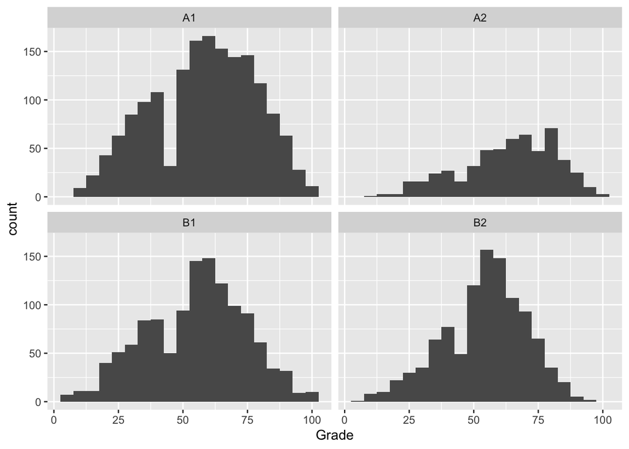

[output not shown]

[output cut: 333 more lines]

[output not shown]

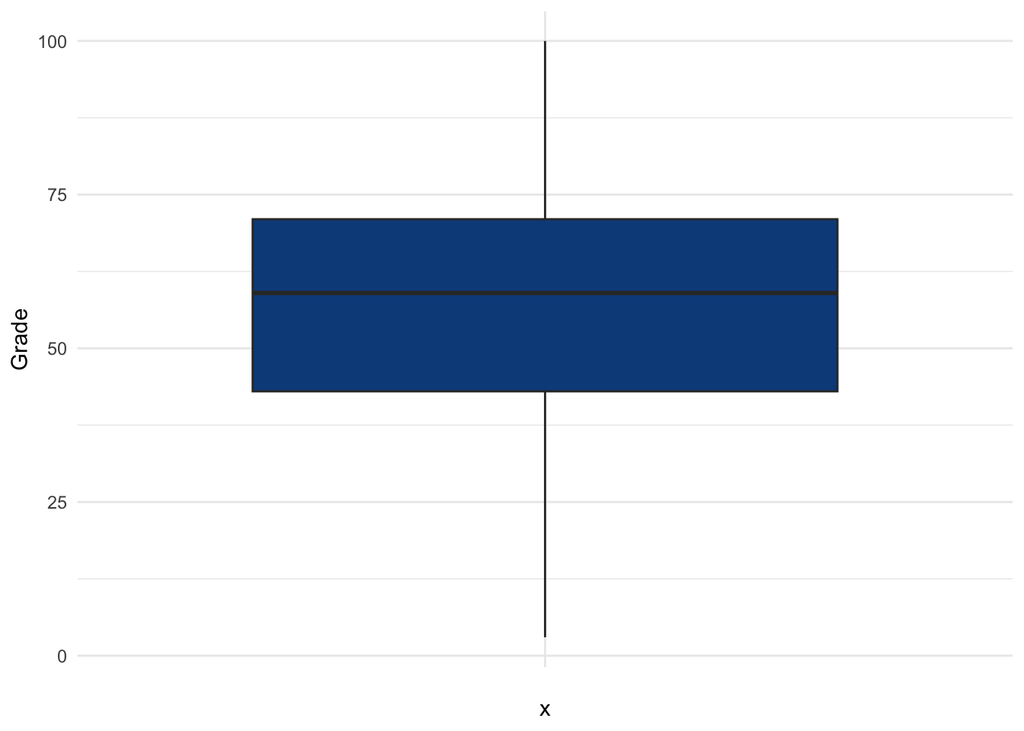

#### Question 4

What is the pass rate for the 1st and 2nd year courses for each year? Are there any differences between A1 and A2?

|  | pass_rate_a1 | pass_rate_a2 | diff_a1_a2 | pass_rate_A | pass_rate_B |
| --- | --- | --- | --- | --- | --- |
| 2015 | 0.802 | 0.847 | -0.045 | 0.817 | 0.795 |
| 2016 | 0.745 | 0.839 | -0.094 | 0.771 | 0.667 |
| 2017 | 0.645 | 0.711 | -0.066 | 0.659 | 0.717 |
| 2018 | 0.595 | 0.774 | -0.179 | 0.649 | 0.751 |
| 2019 | 0.668 | 0.876 | -0.208 | 0.721 | 0.639 |
| 2020 | 0.786 | 0.908 | -0.122 | 0.815 | 0.851 |
| 2021 | 0.51 | 0.452 | 0.058 | 0.5 | 0.379 |
| 2022 | 0.696 | 0.622 | 0.074 | 0.688 | 0.609 |

#### Question 5

How many students fail B1 even if they pass A1 or A2?

```
## [1] 434
```

#### Question 6

What would you suggest the minimum mark obtained should be from 1st year courses so that the student is able to pass B1?

| Term | Subject | Acad.Prog | Grade | ID | Pass |
| --- | --- | --- | --- | --- | --- |
| 2015 | B1 | CB026 | 37 | 290 | 37 |
| 2015 | B1 | CB004 | 46 | 256 | 46 |
| 2015 | B1 | CB020 | 41 | 257 | 41 |
| 2015 | B1 | CB001 | NA | 44 | DPR |
| 2016 | B1 | CB003 | 41 | 556 | 41 |
| 2016 | B1 | CB004 | 40 | 608 | 40 |
| 2016 | B1 | CB011 | 42 | 172 | 42 |
| 2016 | B1 | CB023 | 37 | 264 | 37 |
| 2016 | B1 | CB023 | 40 | 195 | 40 |
| 2016 | B1 | CB001 | 37 | 428 | 37 |

[output cut: 483 more lines]

|  | Term | Subject | Acad.Prog | Grade | ID | Pass |
| --- | --- | --- | --- | --- | --- | --- |
| 1 | 2015 | B1 | CB026 | 37 | 290 | 37 |
| 2 | 2015 | B1 | CB004 | 46 | 256 | 46 |
| 3 | 2015 | B1 | CB020 | 41 | 257 | 41 |
| 4 | 2015 | B1 | CB001 |  | 44 | DPR |
| 5 | 2016 | B1 | CB003 | 41 | 556 | 41 |
| 6 | 2016 | B1 | CB004 | 40 | 608 | 40 |
| 7 | 2016 | B1 | CB011 | 42 | 172 | 42 |
| 8 | 2016 | B1 | CB023 | 37 | 264 | 37 |
| 9 | 2016 | B1 | CB023 | 40 | 195 | 40 |
| 10 | 2016 | B1 | CB001 | 37 | 428 | 37 |

[output cut: 483 more lines]